Cl<sub>1,3</sub> Julian L. Avila-Martinez

Computational Physics & Scientific Software · Python · C++17 · HDF5

# Dirac-Solver: 1D Relativistic Wavepackets & 2D Yukawa Potential Simulations

Gaussian Spinor Wavepacket Evolution, Zitterbewegung & Short-Range Yukawa Scattering

**Author:** Julian L. Avila-Martinez **Affiliation:** Universidad Distrital Francisco José de Caldas **Format:** Quarto Published Notebook & Code

## 📓 Notebook 1: 1D Relativistic Dirac Wavepacket Evolution (dirac_solver_1d_example.ipynb)

⬇ Download Raw .ipynb

# 1D Dirac Solver Example

This notebook demonstrates how to use the `dirac_solver` library to set up and run a simple 1D simulation of a free particle.

In [1]:PYTHON

```
import sys
sys.path.append('..')
import numpy as np
from dirac_solver.geometry import Grid
from dirac_solver.initial_state import GaussianPacket, ConstantSpinor
from dirac_solver.core import DiracProblemBuilder, DiracSolver
from dirac_solver import (
    Grid,
    GaussianPacket,
    ConstantSpinor,
    DiracProblemBuilder,
    DiracSolver,
    FreeParticle,
    YukawaPotential,
    InfiniteWellPotential
)
from dirac_solver import _core
```

## 1. Set up the Simulation Parameters

First, we define the spatial grid for our 1D simulation.

In [2]:PYTHON

```
shape = (400,)
spacing = (0.1)
grid = Grid(shape, spacing)
```

Next, we define the initial state of the particle as a Gaussian wavepacket.

In [3]:PYTHON

```
constant_spinor = ConstantSpinor(momentum=[5, 0, 0])
initial_state = GaussianPacket(constant_spinor, center=[0, 0, 0], spatial_width=1.0)
```

We'll simulate a free particle, so we use the `FreeParticle` potential. We also set periodic boundary conditions.

In [4]:PYTHON

```
potential = FreeParticle().core_potential
boundary_condition = _core.PeriodicBoundary()
```

## 2. Build and Run the Simulation

We use the `DiracProblemBuilder` to assemble all the simulation parameters into a `SimulationProblem` object.

In [5]:PYTHON

```
problem = DiracProblemBuilder() \
    .set_grid(grid) \
    .set_initial_state(initial_state) \
    .set_potential(potential) \
    .set_boundary_condition(boundary_condition) \
    .set_time_parameters(time_step=0.001, total_time=2.0) \
    .build()
```

Now, we can create a `DiracSolver` instance and run the simulation.

In [6]:PYTHON

```
solver = DiracSolver(problem)
```

```
DiracSolver inicializado con el motor C++ 'FDTDLeapfrogIntegrator'.
```

In [7]:PYTHON

```
solver.run_simulation()
```

[output not shown]

[output not shown]

## 3. Visualize the Results

Finally, we can plot the probability density of the spinor field at the end of the simulation.

In [8]:PYTHON

```
solver.plot_probability_density()
```

```
Graficando densidad de probabilidad...
```

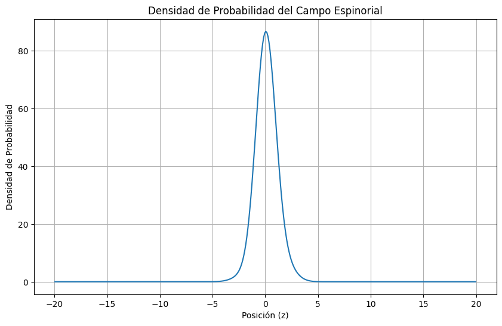

## 4. Examples with other potentials

In [9]:PYTHON

```
solver.run_simulation()
```

[output not shown]

Finally, we can plot the probability density of the spinor field at the end of the simulation.

In [10]:PYTHON

```
yukawa_potential = YukawaPotential(strength=1.0, range=0.5).core_potential
problem_yukawa = DiracProblemBuilder() \
    .set_grid(grid) \
    .set_initial_state(initial_state) \
    .set_potential(yukawa_potential) \
    .set_boundary_condition(boundary_condition) \
    .set_time_parameters(time_step=0.001, total_time=2.0) \
    .build()
solver_yukawa = DiracSolver(problem_yukawa)
solver_yukawa.run_simulation()
solver_yukawa.plot_probability_density()
```

[output not shown]

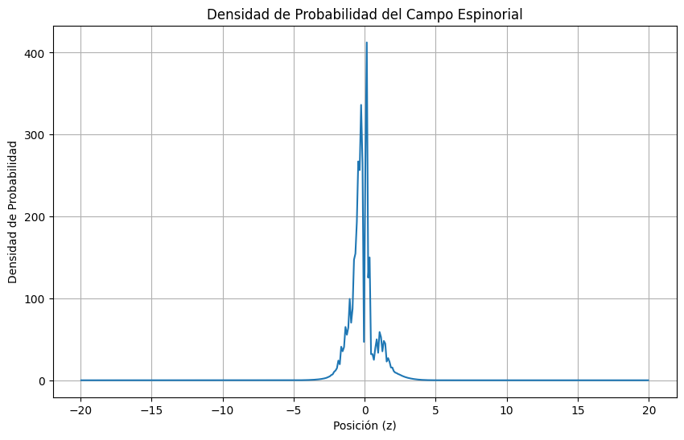

### Infinite Well Potential

In [11]:PYTHON

```
infinite_well_potential = InfiniteWellPotential(widths=[20.0]).core_potential
problem_well = DiracProblemBuilder() \
    .set_grid(grid) \
    .set_initial_state(initial_state) \
    .set_potential(infinite_well_potential) \
    .set_boundary_condition(boundary_condition) \
    .set_time_parameters(time_step=0.001, total_time=2.0) \
    .build()
solver_well = DiracSolver(problem_well)
solver_well.run_simulation()
solver_well.plot_probability_density()
```

[output not shown]

[figure not shown]

## 4. Examples with other potentials

### Yukawa Potential

In [12]:PYTHON

```
yukawa_potential = YukawaPotential(strength=1.0, range=0.5).core_potential
problem_yukawa = DiracProblemBuilder() \
    .set_grid(grid) \
    .set_initial_state(initial_state) \
    .set_potential(yukawa_potential) \
    .set_boundary_condition(boundary_condition) \
    .set_time_parameters(time_step=0.001, total_time=2.0) \
    .build()
solver_yukawa = DiracSolver(problem_yukawa)
solver_yukawa.run_simulation()
solver_yukawa.plot_probability_density()
```

[output not shown]

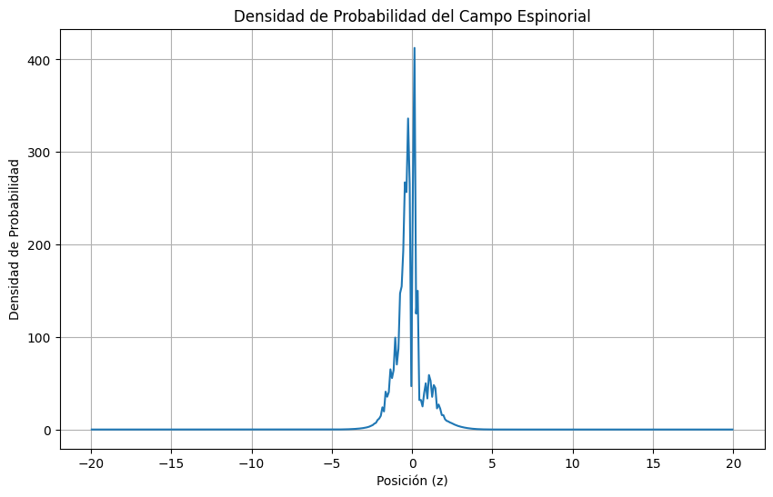

### Infinite Well Potential

In [13]:PYTHON

```
infinite_well_potential = InfiniteWellPotential(widths=[20.0]).core_potential
problem_well = DiracProblemBuilder() \
    .set_grid(grid) \
    .set_initial_state(initial_state) \
    .set_potential(infinite_well_potential) \
    .set_boundary_condition(boundary_condition) \
    .set_time_parameters(time_step=0.001, total_time=2.0) \
    .build()
solver_well = DiracSolver(problem_well)
solver_well.run_simulation()
solver_well.plot_probability_density()
```

[output not shown]

[figure not shown]

## 📓 Notebook 2: Relativistic Fermion in a Yukawa Potential (yukawa.ipynb)

⬇ Download Raw .ipynb

# Ejemplo de Potencial de Yukawa en 2D

Este notebook demuestra cómo: 1. Configurar y ejecutar una simulación 2D de un paquete de ondas gaussiano bajo un potencial de Yukawa. 2. Calcular y graficar observables 2D como la densidad de probabilidad y la corriente de probabilidad. 3. Graficar la evolución temporal de los valores esperados. 4. Generar una animación de la densidad de probabilidad.

In [1]:PYTHON

```
import sys
sys.path.append('..')
import os
import numpy as np
import matplotlib.pyplot as plt
from dirac_solver import (
    Grid,
    GaussianPacket,
    ConstantSpinor,
    DiracProblemBuilder,
    DiracSolver,
    YukawaPotential
)
from dirac_solver.storage import HDF5Storage, create_animation
from dirac_solver.observables import Observables
from dirac_solver.core import _core
```

## 1. Configuración de la Simulación

In [2]:PYTHON

```
# --- Parámetros de la simulación ---
shape = (100, 100)
spacing = (0.1, 0.1)
grid = Grid(shape, spacing)
time_step = 0.002
total_time = 10.0

# --- Estado Inicial: Paquete Gaussiano ---
# Momento en x e y
constant_spinor = ConstantSpinor(momentum=[4, 1, 0])
# Centro desplazado para ver el movimiento
initial_state = GaussianPacket(constant_spinor, center=[-2, -2, 0], spatial_width=1.0)

# --- Potencial de Yukawa ---
# V(r) = -V0 * exp(-a*r) / r
strength = 5.0 # V0
interaction_range = 2.0 # a
potential = YukawaPotential(strength=strength, range=interaction_range).core_potential

# --- Condiciones de Borde ---
boundary_condition = _core.PeriodicBoundary()

# --- Construcción del Problema ---
problem = DiracProblemBuilder() \
    .set_grid(grid) \
    .set_initial_state(initial_state) \
    .set_potential(potential) \
    .set_boundary_condition(boundary_condition) \
    .set_time_parameters(time_step, total_time) \
    .build()

solver = DiracSolver(problem)
```

```
DiracSolver inicializado con el motor C++ 'FDTDLeapfrogIntegrator'.
```

## 2. Ejecución de la Simulación y Cálculo de Observables

In [3]:PYTHON

```
# --- Archivos de salida ---
output_dir = 'output'
os.makedirs(output_dir, exist_ok=True)
hdf5_path = os.path.join(output_dir, 'yukawa_2d.hdf5')
animation_path = os.path.join(output_dir, 'yukawa_2d.gif')

# --- Inicializar manejadores ---
storage = HDF5Storage(hdf5_path, problem)
observables = Observables(solver)

# --- Ejecutar la simulación ---
# save_every_n_steps=10 para no generar demasiados datos
solver.run_simulation(
    storage_handler=storage,
    observables_handler=observables,
    save_every_n_steps=10
)
```

[output not shown]

[output not shown]

## 3. Visualización de Valores Esperados

In [4]:PYTHON

```
time = observables.get_history('time')
expected_pos = observables.get_history('expected_position')
expected_mom = observables.get_history('expected_momentum')
expected_energy = observables.get_history('expected_energy')

plt.figure(figsize=(12, 10))

# Posición Esperada X e Y
plt.subplot(3, 1, 1)
plt.plot(time, expected_pos[:, 0], label='<x>')
plt.plot(time, expected_pos[:, 1], label='<y>')
plt.ylabel('Posición Esperada')
plt.legend()
plt.grid(True)
plt.title('Evolución de la Posición Esperada')

# Momento Esperado X e Y
plt.subplot(3, 1, 2)
plt.plot(time, expected_mom[:, 0], label='<px>')
plt.plot(time, expected_mom[:, 1], label='<py>')
plt.ylabel('Momento Esperado')
plt.legend()
plt.grid(True)
plt.title('Evolución del Momento Esperado')

# Energía Esperada
plt.subplot(3, 1, 3)
plt.plot(time, expected_energy)
plt.ylabel('Energía Esperada <E>')
plt.xlabel('Tiempo')
plt.grid(True)
plt.title('Evolución de la Energía Esperada')

plt.tight_layout()
plt.show()
```

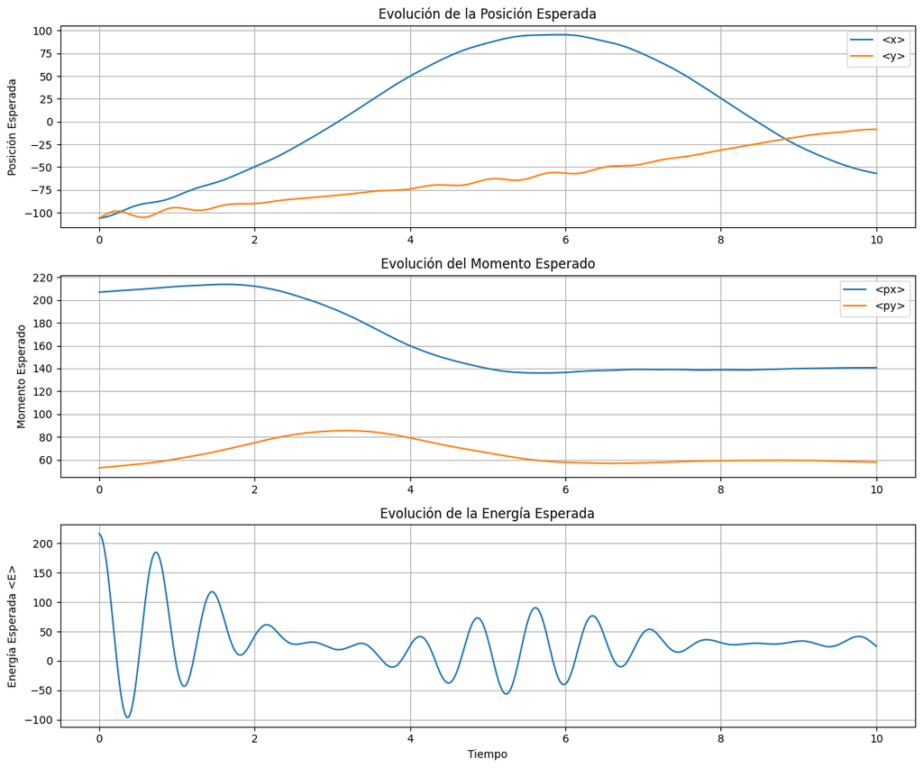

## 4. Visualización 2D: Densidad y Corriente de Probabilidad

Mostramos el estado final de la simulación.

In [5]:PYTHON

```
# Recuperamos los últimos datos guardados en el historial
last_prob_density = observables.get_history('probability_density')[-1]
last_prob_current = observables.get_history('probability_current')[-1]

# Reshape para la malla 2D
rho_grid = last_prob_density.reshape(shape)
jx_grid = last_prob_current[:, 0].reshape(shape)
jy_grid = last_prob_current[:, 1].reshape(shape)

# Coordenadas para graficar
x = np.linspace(grid.origin[0], grid.origin[0] + (shape[0]-1)*spacing[0], shape[0])
y = np.linspace(grid.origin[1], grid.origin[1] + (shape[1]-1)*spacing[1], shape[1])
X, Y = np.meshgrid(x, y, indexing='ij')

plt.figure(figsize=(10, 8))

# Graficar densidad de probabilidad como mapa de calor
plt.imshow(rho_grid.T, origin='lower', extent=[x[0], x[-1], y[0], y[-1]], cmap='viridis', alpha=0.8)
plt.colorbar(label='Densidad de Probabilidad')

# Graficar corriente de probabilidad como vectores (quiver)
# Submuestreamos para que no se vea muy denso el gráfico de flechas
skip = 5
plt.quiver(X[::skip, ::skip], Y[::skip, ::skip],
           jx_grid[::skip, ::skip], jy_grid[::skip, ::skip],
           color='white', pivot='mid', scale=None)

plt.title(f'Densidad y Corriente de Probabilidad en t={total_time}')
plt.xlabel('x')
plt.ylabel('y')
plt.show()
```

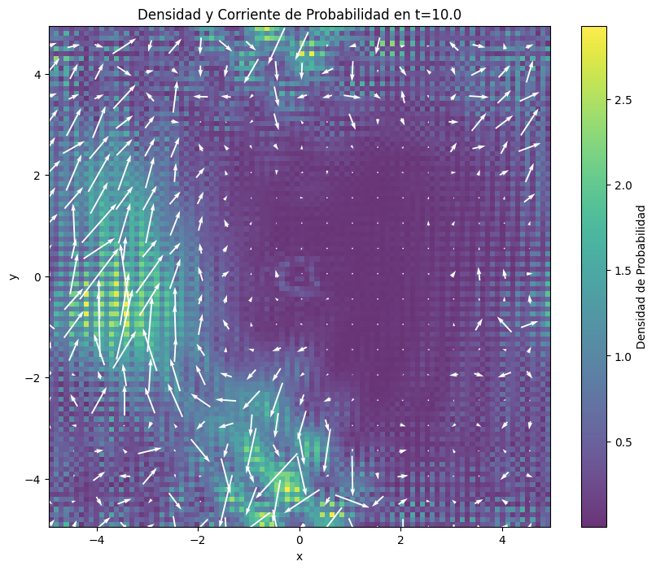

In [6]:PYTHON

```
print(f"Generando animación a partir de {hdf5_path}...")
create_animation(hdf5_path, animation_path, interval=100)
print(f"Animación guardada en: {animation_path}")
```

```
Generando animación a partir de output/yukawa_2d.hdf5...
```

[output not shown]

[output not shown]

[output not shown]

[output not shown]

[figure not shown]

## 💻 Pauli & Dirac Constant Spinor / Gaussian Wavepacket Initialization (initial_state.py)

⬇ View Raw Source (initial_state.py)

projects/02-computational-physics-and-software/dirac-equation-solver/dirac_solver/initial_state.pyPYTHON

```
"""
@file initial_state.py
@brief Creación del estado inicial sin geometría del espacio.
"""

import numpy as np
from abc import ABC, abstractmethod
from . import c, hbar, electron_mass, sigma_1, sigma_2, sigma_3


class InitialState(ABC):
    """
    Clase Base Abstracta para todos los estados iniciales.
    Define el "contrato" que todos los estados iniciales deben cumplir.
    """
    def __init__(self, mass=electron_mass):
        self.mass = mass

    @abstractmethod
    def evaluate(self, grid_position):
        """
        Calcula el espinor en un punto específico del espacio.
        """
        pass

    @abstractmethod
    def evaluate_on_grid(self, grid):
        """
        Calcula el espinor en toda la malla.
        """
        pass


class ConstantSpinor:
    """
    Prepara el estado inicial de un espinor constante (sin considerar la geometría del espacio).
    """
    def __init__(self, spin_polarization=[0,0,1], spin_superposition=[1 + 0j, 0 + 0j], momentum=[1,0,0], mass=electron_mass):
        """
        Constructor del espinor constante.
        """
        # Se normaliza el vector (al necesitarse un vector unitario)
        norm_n = np.linalg.norm(spin_polarization)
        self.spin_polarization = np.array(spin_polarization) / norm_n if norm_n > 0 else np.array([0,0,1])

        # Se comprueba que la suma del módulo al cuadrado sea 1
        norm_s = np.linalg.norm(spin_superposition)
        self.spin_superposition = np.array(spin_superposition, dtype=np.complex128) / norm_s if norm_s > 0 else np.array([1,0])

        self.momentum = np.array(momentum)
        self.mass = mass

        self._base()
        self._pauli_spinor()
        self._constant_spinor()

    def _base(self):
        """
        Calcula la base del espinor de Pauli.
        """
        theta = np.arccos(self.spin_polarization[2])
        phi = np.arctan2(self.spin_polarization[1], self.spin_polarization[0])

        # Construcción base (vector columna 2x1) del espinor de Pauli
        self.chi_up = np.array([
            [np.cos(theta / 2)],
            [np.exp(1j * phi) * np.sin(theta / 2)]
        ], dtype=np.complex128)

        self.chi_down = np.array([
            [np.sin(theta / 2)],
            [-np.exp(1j * phi) * np.cos(theta / 2)]
        ], dtype=np.complex128)

    def _pauli_spinor(self):
        """
        Construcción del espinor de Pauli.
        """
        alpha = self.spin_superposition[0]
        beta = self.spin_superposition[1]
        self.pauli_spinor = (alpha * self.chi_up) + (beta * self.chi_down)

    def _constant_spinor(self):
        """
        Construcción del espinor constante (por partes).
        """
        # Proyección del spin en la dirección del momento
        norm_momentum = np.linalg.norm(self.momentum)

        if norm_momentum == 0:
            proyection_spin = np.zeros((2, 2), dtype=np.complex128)
        else:
            proyection_spin = ((self.momentum[0] * sigma_1 +
                                self.momentum[1] * sigma_2 +
                                self.momentum[2] * sigma_3) / norm_momentum)

        # Energía relativista
        energy = np.sqrt((norm_momentum)**2 + (self.mass)**2)

        # Partes superior e inferior del espinor
        upper_part = np.sqrt(energy + self.mass) * self.pauli_spinor
        lower_part = np.sqrt(energy - self.mass) * (proyection_spin @ self.pauli_spinor)

        self.constant_spinor = np.vstack((upper_part, lower_part))


class GaussianPacket(InitialState):
    """
    Clase que construye el estado inicial como un paquete de ondas gaussianas.
    """
    def __init__(self, constant_spinor, center=[0,0,0], spatial_width=1):
        """
        Constructor.
         constant_spinor: El espinor constante base.
         center: Centro del paquete gaussiano.
         spatial_width: Ancho espacial del paquete.
        """
        super().__init__(constant_spinor.mass)
        self.constant_spinor = constant_spinor
        self.center = np.array(center)
        self.spatial_width = spatial_width

    def evaluate(self, grid_position):
        """
        Calcula el estado base en un punto exacto.
        """
        x = np.array(grid_position)
        p0 = self.constant_spinor.momentum
        x0 = self.center

        # Rellenar el vector de posición 'x' para que coincida con la dimensión del vector de momento y centro
        if x.shape[0] < p0.shape[0]:
            padded_x = np.zeros(p0.shape[0], dtype=float)
            padded_x[:x.shape[0]] = x
            x = padded_x

        if x0.shape[0] < p0.shape[0]:
            padded_x0 = np.zeros(p0.shape[0], dtype=float)
            padded_x0[:x0.shape[0]] = x0
            x0 = padded_x0

        sigma0 = self.spatial_width
        u_p0 = self.constant_spinor.constant_spinor

        p0_dot_x = np.dot(p0, x)
        exponent_norm = np.linalg.norm(x - x0)**2

        spatial_part = np.exp(1j * p0_dot_x) * np.exp(-exponent_norm / (4 * sigma0**2))

        dirac_spinor = u_p0 * spatial_part

        return dirac_spinor

    def evaluate_on_grid(self, grid):
        """
        Calcula el estado inicial en toda la malla.
         grid: Objeto Grid sobre el que se evaluará el paquete.
        @return: Un array de NumPy con la forma (n_points, 4).
        """
        n_points = np.prod(grid.shape)
        psi_0 = np.zeros((n_points, 4), dtype=np.complex128)

        coords_flat = grid.coords.reshape(n_points, grid.dim)

        for i in range(n_points):
            position = coords_flat[i]
            spinor_at_point = self.evaluate(position)
            psi_0[i, :] = spinor_at_point.flatten()

        return psi_0


class PlaneWave(InitialState):
    """
    Clase que construye el estado inicial como una Onda Plana.
    Hereda de InitialState.
    """
    def __init__(self, constant_spinor):
        """
        Constructor.
         constant_spinor: El espinor constante base.
        """
        super().__init__(constant_spinor.mass)
        self.constant_spinor = constant_spinor

    def evaluate(self, grid_position):
        """
        Calcula el estado base en un punto exacto.
        """
        x = np.array(grid_position)
        p0 = self.constant_spinor.momentum

        if len(x) < len(p0):
            padded_x = np.zeros(len(p0), dtype=float)
            padded_x[:len(x)] = x.flatten()
            x = padded_x

        u_p0 = self.constant_spinor.constant_spinor

        p0_dot_x = np.dot(p0, x)

        # Parte espacial de la Onda plana
        spatial_part = np.exp(1j * p0_dot_x)

        dirac_spinor = u_p0 * spatial_part

        return dirac_spinor


    def evaluate_on_grid(self, grid):
        """
        Calcula el estado inicial en toda la malla.
         grid: Objeto Grid sobre el que se evaluará el paquete.
        @return: Un array de NumPy con la forma (n_points, 4).
        """
        n_points = np.prod(grid.shape)
        psi_0 = np.zeros((n_points, 4), dtype=np.complex128)

        coords_flat = grid.coords.reshape(n_points, grid.dim)

        for i in range(n_points):
            position = coords_flat[i]
            spinor_at_point = self.evaluate(position)
            psi_0[i, :] = spinor_at_point.flatten()

        return psi_0
```

## 💻 C++17 Yukawa & Coulomb Potentials (YukawaPotential.h)

⬇ View Raw Source (YukawaPotential.h)

projects/02-computational-physics-and-software/dirac-equation-solver/cpp_src/potentials/YukawaPotential.hCPP

```
#pragma once

#include "Potential.h"
#include <cmath>
#include <numeric>

///////////////////////////////////////////////////////////////
/// @class YukawaPotential
/// @brief Implementación de un potencial de Yukawa.
///
/// Esta clase deriva de la clase abstracta @ref Potential y define
/// un potencial de Yukawa, que es un potencial de corto alcance.
///
/// La expresión implementada es:
///
///   \\[   V(r) = -V_0 \\frac{e^{-ar}}{r} \\]
///
///
/// donde:
/// - \\( V_0 \\) es la fuerza del potencial.
/// - \\( a \\) es el parámetro de rango.
///
/// @note Este potencial puede emplearse tanto en simulaciones 1D, 2D o 3D.
///////////////////////////////////////////////////////////////
class YukawaPotential : public Potential {
public:
    ///////////////////////////////////////////////////////////
    /// @brief Constructor principal del potencial de Yukawa.
    ///
    /// @param strength La fuerza del potencial (V_0).
    /// @param range El rango del potencial (a).
    ///////////////////////////////////////////////////////////
    YukawaPotential(double strength, double range)
        : strength_(strength), range_(range) {}

    ///////////////////////////////////////////////////////////
    /// @brief Evalúa el potencial en un punto espacial.
    ///
    /// @param r Vector de posición (1D, 2D o 3D).
    /// @return Valor escalar del potencial \\( V(r) \\).
    ///////////////////////////////////////////////////////////
    double evaluate(const std::vector<double>& r) const override {
        double r_norm = 0.0;
        for (double val : r) {
            r_norm += val * val;
        }
        r_norm = std::sqrt(r_norm);

        if (r_norm == 0.0) {
            return -strength_;
        }

        return -strength_ * std::exp(-range_ * r_norm) / r_norm;
    }

    ///////////////////////////////////////////////////////////
    /// @brief Devuelve el nombre simbólico del potencial.
    ///
    /// @return Cadena con el nombre `"YukawaPotential"`.
    ///////////////////////////////////////////////////////////
    std::string get_name() const override {
        return "YukawaPotential";
    }

private:
    double strength_;
    double range_;
};
```